# R Notebook

```r
library(tidyverse)
```

```r
diamonds <- read_csv("diamonds.csv")
```

```r
View(diamonds)
```

```r
diamonds_temp <- diamonds %>%
  select("carat", "x", "y", "z")
```

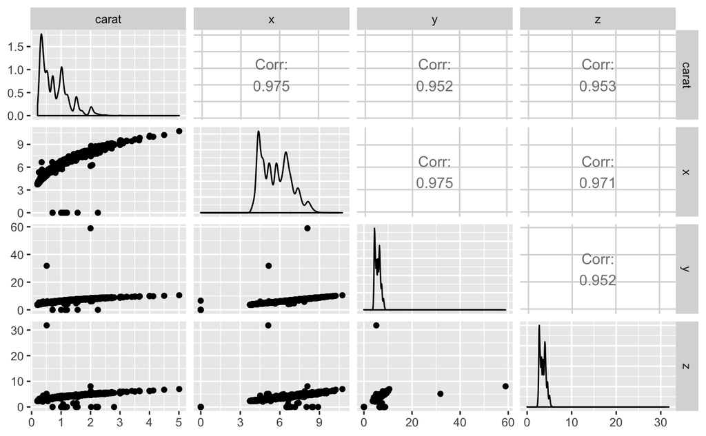

```r
library(GGally)

ggpairs(diamonds_temp)
```

As we can see there is substancial correlation between these 4 variables, Let us drop x , y and z and work only with carat hence forth in the data set

```r
diamonds <- diamonds %>%
  select(-c("X1", "x", "y", "z"))

View(diamonds)
```

Let us now create a regression model for the price of a diamond in terms of the possible predictor variables in the dataset.

Let us Use ggpairs() to investigate correlations between price and the predictors.

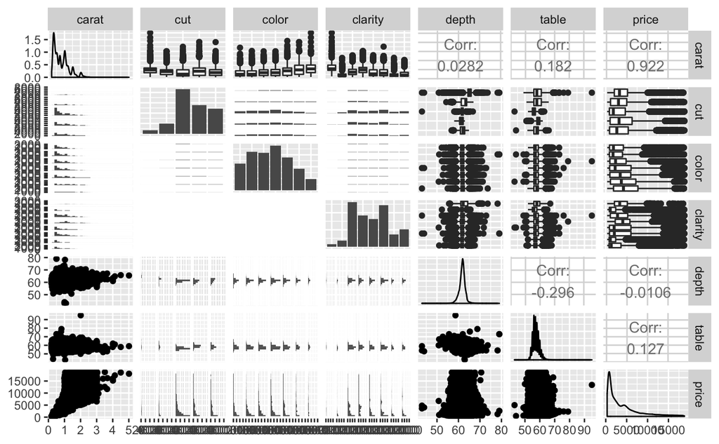

```r
ggpairs(diamonds)
```

Perform further ggplot visualisations of any significant correlations you find.

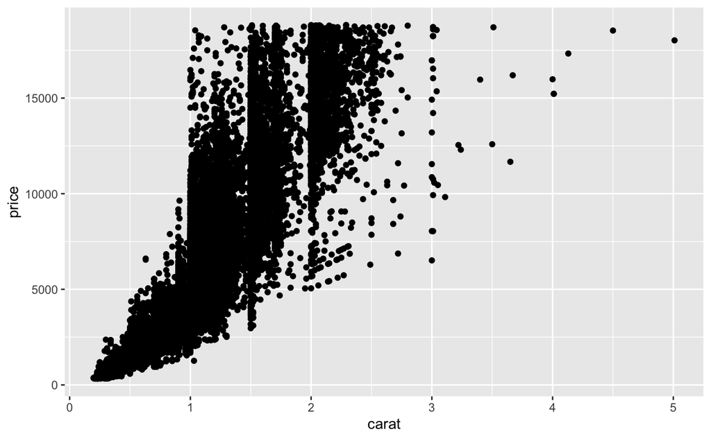

```r
diamonds %>%
  ggplot(aes(x = carat, y = price)) +
  geom_point()
```

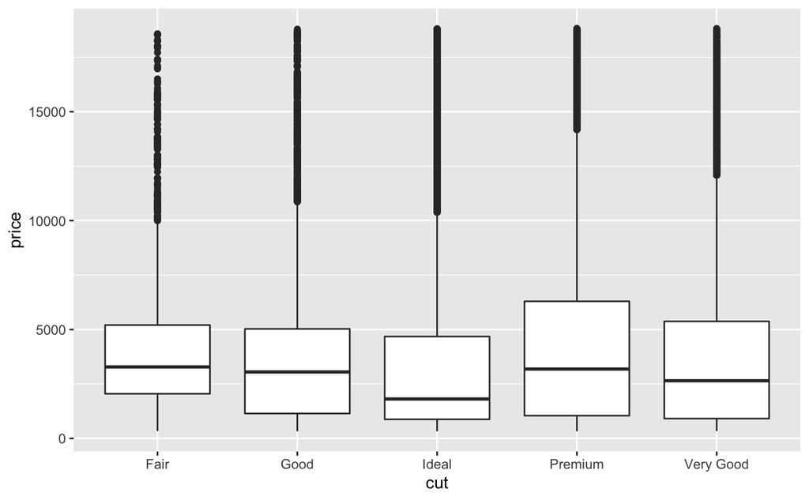

```r
diamonds %>%
  ggplot(aes(x = cut , y = price)) +
  geom_boxplot()
```

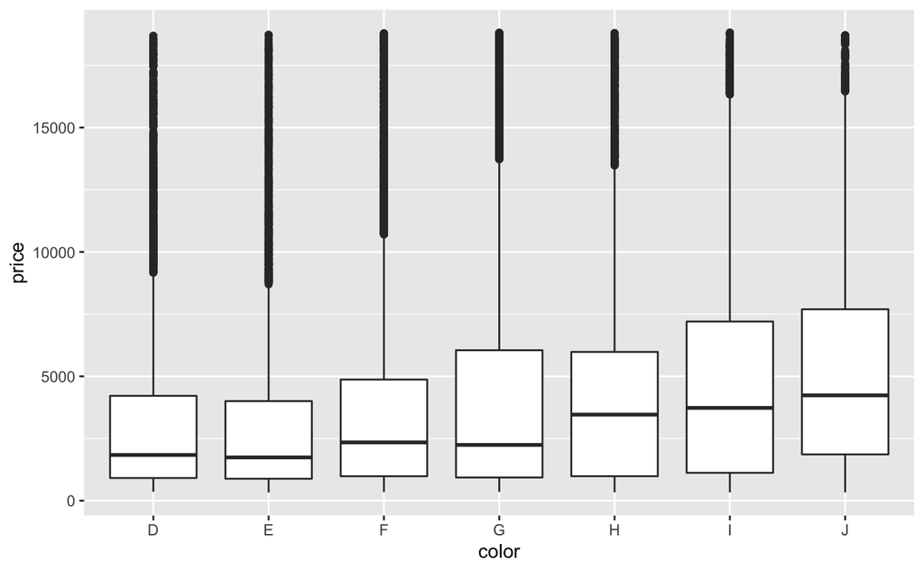

```r
diamonds %>%
  ggplot(aes(x = color , y = price)) +
  geom_boxplot()
```

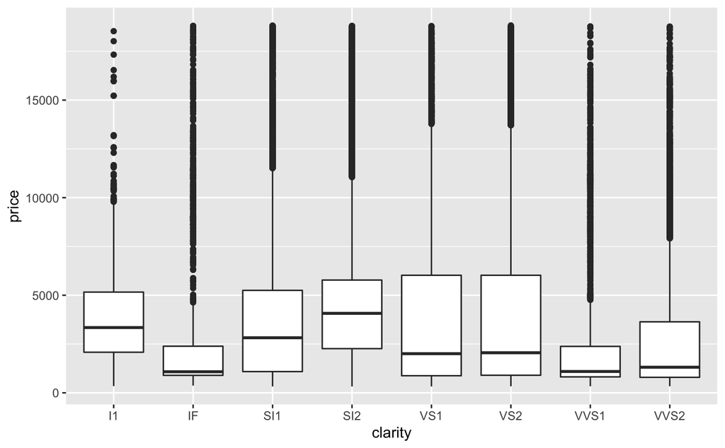

```r
diamonds %>%
  ggplot(aes(x = clarity , y = price)) +
  geom_boxplot()
```

Now we can try a regression fit using one or more of the categorical predictors cut, clarity and color, so let’s investigate these predictors: Investigate the factor levels of these predictors. Looks like we might have 4 dummies for Cut :Fair, Good, Very Good, Premium, Ideal 6 dummies for Color : D , E , F, G, H, I, J 7 dumies for Clarity :I1, SI2, SI1, VS2, VS1, VVS2, VVS1, IF

Please note in the outcome we will always loose 1 varaible column.

```r
diamonds_dummycut <- diamonds %>%
  fastDummies::dummy_cols(select_columns = "cut", remove_first_dummy = TRUE)

diamonds_dummycut
```

| carat | cut | color | clarity | depth | table | price | cut_Good | cut_Ideal | cut_Premium | cut_Very Good |
| --- | --- | --- | --- | --- | --- | --- | --- | --- | --- | --- |
| 0.23 | Ideal | E | SI2 | 61.5 | 55.0 | 326 | 0 | 1 | 0 | 0 |
| 0.21 | Premium | E | SI1 | 59.8 | 61.0 | 326 | 0 | 0 | 1 | 0 |
| 0.23 | Good | E | VS1 | 56.9 | 65.0 | 327 | 1 | 0 | 0 | 0 |
| 0.29 | Premium | I | VS2 | 62.4 | 58.0 | 334 | 0 | 0 | 1 | 0 |
| 0.31 | Good | J | SI2 | 63.3 | 58.0 | 335 | 1 | 0 | 0 | 0 |
| 0.24 | Very Good | J | VVS2 | 62.8 | 57.0 | 336 | 0 | 0 | 0 | 1 |
| 0.24 | Very Good | I | VVS1 | 62.3 | 57.0 | 336 | 0 | 0 | 0 | 1 |
| 0.26 | Very Good | H | SI1 | 61.9 | 55.0 | 337 | 0 | 0 | 0 | 1 |
| 0.22 | Fair | E | VS2 | 65.1 | 61.0 | 337 | 0 | 0 | 0 | 0 |
| 0.23 | Very Good | H | VS1 | 59.4 | 61.0 | 338 | 0 | 0 | 0 | 1 |

[output cut: 990 more lines]

```r
diamonds_dummycolor <- diamonds %>%
  fastDummies::dummy_cols(select_columns = "color", remove_first_dummy = TRUE)

diamonds_dummycolor
```

| carat | cut | color | clarity | depth | table | price | color_E | color_F | color_G | color_H | color_I | color_J |
| --- | --- | --- | --- | --- | --- | --- | --- | --- | --- | --- | --- | --- |
| 0.23 | Ideal | E | SI2 | 61.5 | 55.0 | 326 | 1 | 0 | 0 | 0 | 0 | 0 |
| 0.21 | Premium | E | SI1 | 59.8 | 61.0 | 326 | 1 | 0 | 0 | 0 | 0 | 0 |
| 0.23 | Good | E | VS1 | 56.9 | 65.0 | 327 | 1 | 0 | 0 | 0 | 0 | 0 |
| 0.29 | Premium | I | VS2 | 62.4 | 58.0 | 334 | 0 | 0 | 0 | 0 | 1 | 0 |
| 0.31 | Good | J | SI2 | 63.3 | 58.0 | 335 | 0 | 0 | 0 | 0 | 0 | 1 |
| 0.24 | Very Good | J | VVS2 | 62.8 | 57.0 | 336 | 0 | 0 | 0 | 0 | 0 | 1 |
| 0.24 | Very Good | I | VVS1 | 62.3 | 57.0 | 336 | 0 | 0 | 0 | 0 | 1 | 0 |
| 0.26 | Very Good | H | SI1 | 61.9 | 55.0 | 337 | 0 | 0 | 0 | 1 | 0 | 0 |
| 0.22 | Fair | E | VS2 | 65.1 | 61.0 | 337 | 1 | 0 | 0 | 0 | 0 | 0 |
| 0.23 | Very Good | H | VS1 | 59.4 | 61.0 | 338 | 0 | 0 | 0 | 1 | 0 | 0 |

[output cut: 990 more lines]

```r
diamonds_dummyclarity <- diamonds %>%
  fastDummies::dummy_cols(select_columns = "clarity", remove_first_dummy = TRUE)

diamonds_dummyclarity
```

| carat | cut | color | clarity | depth | table | price | clarity_IF | clarity_SI1 | clarity_SI2 | clarity_VS1 | clarity_VS2 | clarity_VVS1 | clarity_VVS2 |
| --- | --- | --- | --- | --- | --- | --- | --- | --- | --- | --- | --- | --- | --- |
| 0.23 | Ideal | E | SI2 | 61.5 | 55.0 | 326 | 0 | 0 | 1 | 0 | 0 | 0 | 0 |
| 0.21 | Premium | E | SI1 | 59.8 | 61.0 | 326 | 0 | 1 | 0 | 0 | 0 | 0 | 0 |
| 0.23 | Good | E | VS1 | 56.9 | 65.0 | 327 | 0 | 0 | 0 | 1 | 0 | 0 | 0 |
| 0.29 | Premium | I | VS2 | 62.4 | 58.0 | 334 | 0 | 0 | 0 | 0 | 1 | 0 | 0 |
| 0.31 | Good | J | SI2 | 63.3 | 58.0 | 335 | 0 | 0 | 1 | 0 | 0 | 0 | 0 |
| 0.24 | Very Good | J | VVS2 | 62.8 | 57.0 | 336 | 0 | 0 | 0 | 0 | 0 | 0 | 1 |
| 0.24 | Very Good | I | VVS1 | 62.3 | 57.0 | 336 | 0 | 0 | 0 | 0 | 0 | 1 | 0 |
| 0.26 | Very Good | H | SI1 | 61.9 | 55.0 | 337 | 0 | 1 | 0 | 0 | 0 | 0 | 0 |
| 0.22 | Fair | E | VS2 | 65.1 | 61.0 | 337 | 0 | 0 | 0 | 0 | 1 | 0 | 0 |
| 0.23 | Very Good | H | VS1 | 59.4 | 61.0 | 338 | 0 | 0 | 0 | 1 | 0 | 0 | 0 |

[output cut: 990 more lines]

Going forward we’ll let R handle dummy variable creation for categorical predictors in regression fitting (remember lm() will generate the correct numbers of dummy levels automatically, absorbing one of the levels into the intercept as a reference level)

Let us now start with simple linear regression.

Let us Regress price on carat and check the regression diagnostics.

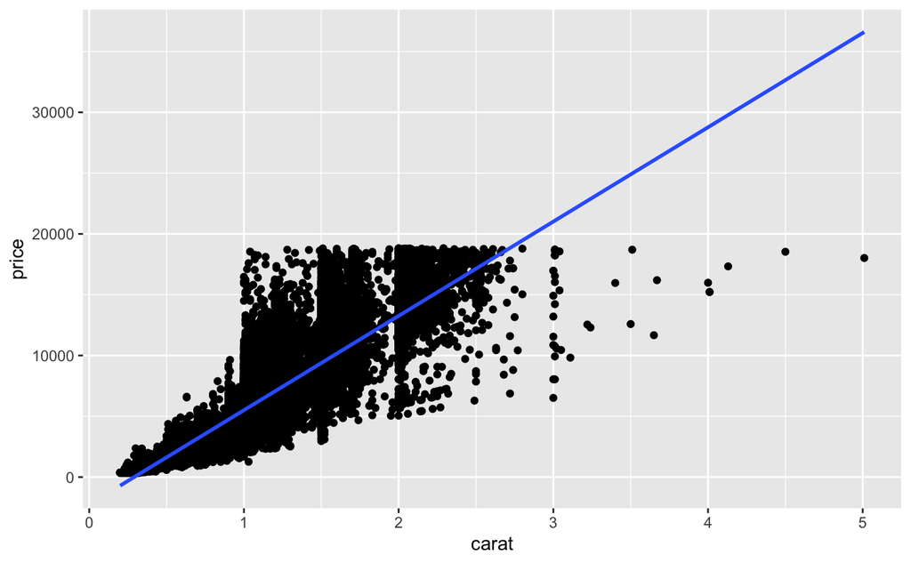

```r
diamonds %>%
  ggplot(aes(x = carat, y = price)) +
  geom_point() +
  geom_smooth(method = "lm", se = FALSE)
```

```r
model <- lm(price ~ carat, data = diamonds)
summary(model)
```

```
Call:
lm(formula = price ~ carat, data = diamonds)

Residuals:
     Min       1Q   Median       3Q      Max
-18585.3   -804.8    -18.9    537.4  12731.7

Coefficients:
            Estimate Std. Error t value Pr(>|t|)
(Intercept) -2256.36      13.06  -172.8   <2e-16 ***
carat        7756.43      14.07   551.4   <2e-16 ***
---
Signif. codes:  0 ‘***’ 0.001 ‘**’ 0.01 ‘*’ 0.05 ‘.’ 0.1 ‘ ’ 1

Residual standard error: 1549 on 53938 degrees of freedom
Multiple R-squared:  0.8493,    Adjusted R-squared:  0.8493
F-statistic: 3.041e+05 on 1 and 53938 DF,  p-value: < 2.2e-16
```

We can see that R-squared: 0.8493 (coefficient of determination) is almost close to 1 and we can also see p Value has got *** , hence we can say that its a good fit.

let us also take a look at the diagnostic plots

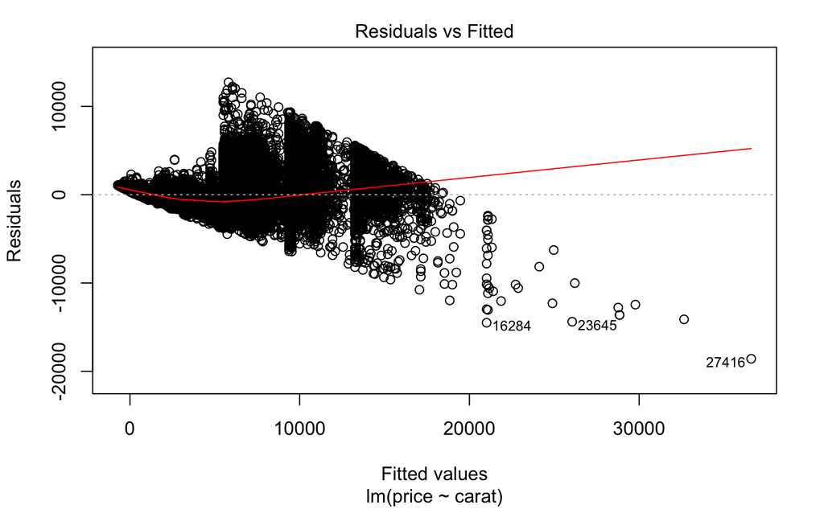

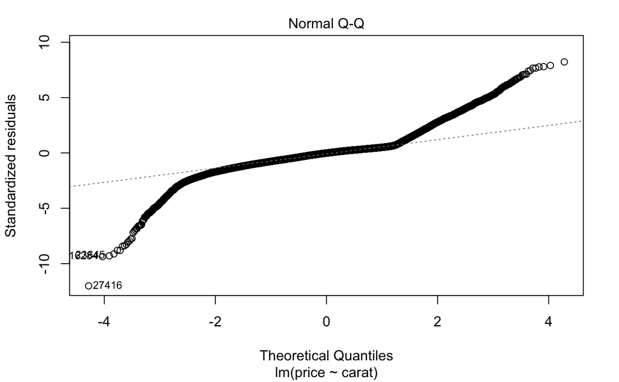

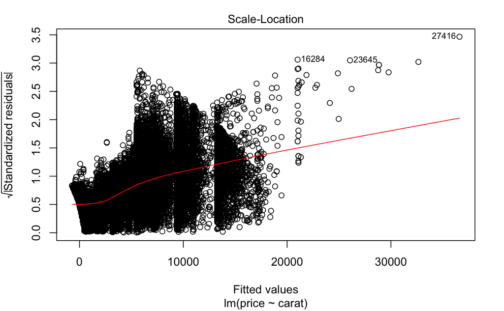

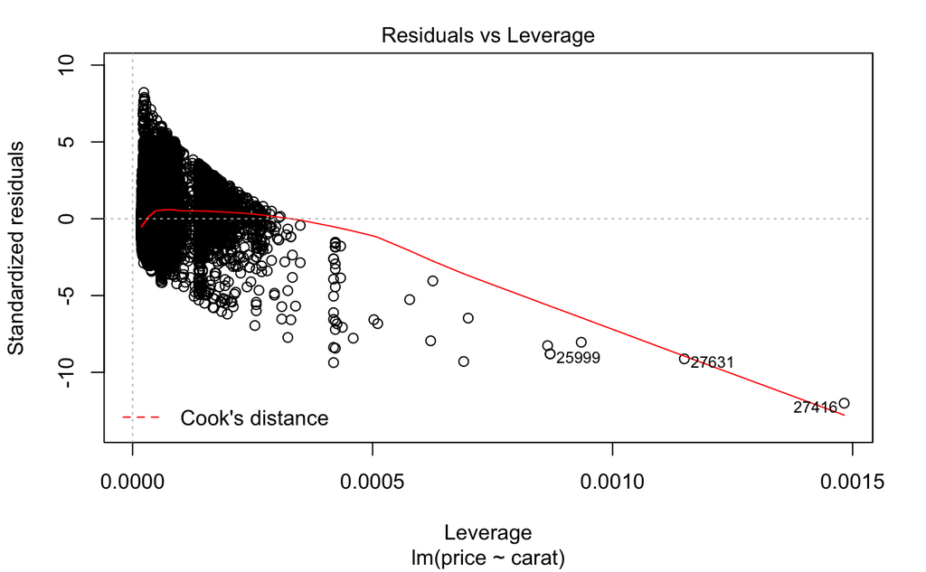

```r
plot(model)
```

Obesrvations :

Also, Normal Q-Q graph has quiet a considerable number of deviations both top and bottom.

```r
model2 <- lm(price ~ carat + cut + clarity+ color, data = diamonds)

summary(model2)
```

```
Call:
lm(formula = price ~ carat + cut + clarity + color, data = diamonds)

Residuals:
     Min       1Q   Median       3Q      Max
-16813.5   -680.4   -197.6    466.4  10394.9

Coefficients:
             Estimate Std. Error t value Pr(>|t|)
(Intercept)  -7362.80      51.68 -142.46   <2e-16 ***
carat         8886.13      12.03  738.44   <2e-16 ***
cutGood        655.77      33.63   19.50   <2e-16 ***
cutIdeal       998.25      30.66   32.56   <2e-16 ***
cutPremium     869.40      30.93   28.11   <2e-16 ***
cutVery Good   848.72      31.28   27.14   <2e-16 ***
clarityIF     5419.65      52.14  103.95   <2e-16 ***
claritySI1    3573.69      44.60   80.13   <2e-16 ***
claritySI2    2625.95      44.79   58.63   <2e-16 ***
clarityVS1    4534.88      45.54   99.59   <2e-16 ***
clarityVS2    4217.83      44.84   94.06   <2e-16 ***
clarityVVS1   5072.03      48.21  105.20   <2e-16 ***
clarityVVS2   4967.20      46.89  105.93   <2e-16 ***
colorE        -211.68      18.32  -11.56   <2e-16 ***
colorF        -303.31      18.51  -16.39   <2e-16 ***
colorG        -506.20      18.12  -27.93   <2e-16 ***
colorH        -978.70      19.27  -50.78   <2e-16 ***
colorI       -1440.30      21.65  -66.54   <2e-16 ***
colorJ       -2325.22      26.72  -87.01   <2e-16 ***
---
Signif. codes:  0 ‘***’ 0.001 ‘**’ 0.01 ‘*’ 0.05 ‘.’ 0.1 ‘ ’ 1

Residual standard error: 1157 on 53921 degrees of freedom
Multiple R-squared:  0.9159,    Adjusted R-squared:  0.9159
F-statistic: 3.264e+04 on 18 and 53921 DF,  p-value: < 2.2e-16
```